# 1. For Loops

For Loops sind Schleifen, die eine Aufgabe so lange wiederholen bis ein Ende erreicht wird. Dies ist ein wichtiges Tool für Automatisierungen.

Zuerst werden aber noch alle benötigten Module importiert

```python
import pandas as pd
```

```python
import geopandas as gpd
```

```python
import random
```

**Übung 1: Erste For-Loop erstellen**

```python
for platzhalterName in ["Isabelle","Annina","Sara"]:
              print ("Hallo",platzhalterName)
```

```
Hallo Isabelle
Hallo Annina
Hallo Sara
```

**Übung 2: For-Loop mit range()**

```python
for platzhalterNum in range(3):
    print (platzhalterNum)
```

```
0
1
2
```

Note: für Zahlenwerte braucht es keine eckigen Klammern um den Iterator

**Übung 3: Output aus For-Loop speichern**

```python
stropheGruss = []
for platzhalterName in ["Isabelle","Annina","Sara"]:
    gruss = "Hallo " + platzhalterName
    stropheGruss.append(gruss)
```

```python
stropheGruss
```

```
['Hallo Isabelle', 'Hallo Annina', 'Hallo Sara']
```

# 2. Zeckenstichsimulation mit Loop

```python
from shapely.geometry import Point
```

**Übung 4: Mit For-Loop Monte-Carlo-Simulation durchführen**

```python
def point_offset(point, distance = 100):
    x_alt = point.x
    y_alt = point.y

    distance = int(distance)

    x_neu = x_alt + random.randrange(-distance,distance)
    y_neu = y_alt + random.randrange(-distance,distance)

    point_off = Point(x_neu, y_neu)

    return(point_off)
```

```python
Funktion "point offset" erstellt neue Koordianten mit einem zufälligen Versatz
```

```python
zeckenstiche = gpd.read_file("zeckenstiche.shp")
```

WorkingDirectory in Jupyter Notebook: Dateien, auf die zugegriffen werden soll, können auf der Jupyter Home Page importiert werden. Darin werden hinzugefügte Files automatisch gefunden.

```python
   montecarlo =[]

for runs in range(50): #0



    zeckenstiche_sim = gpd.GeoDataFrame() #1

    zeckenstiche_sim["geometry"] = zeckenstiche["geometry"].apply(point_offset) #2

    zeckenstiche_sim["ID"]=zeckenstiche["ID"] #3

    zeckenstiche_sim["Run_Nr"]=runs #4

    montecarlo.append(zeckenstiche_sim) #5
```

#0 definiert 50 runs für die nachfolgende Aktion #1 erstellt ein leeres GeoDataFrame #2 erstellt Spalte und generiert mit Funktion "point offset" veränderte Koordinaten #3 kopiert Spalte "ID" aus Originaldaten in das neue DataFrame #4 erstellt Spalte "Run_Nr", die auf Funktion "runs" mit 50 Durchgängen verweist # "montecarlo" erstellt Liste der 50 Durchgänge "montecarlo" enthält nun 50 dataframes mit random verschobenen Punkten

**Übung 5: GeoDataframes aus Simulation zusammenführen**

```python
type(zeckenstiche_sim)
```

```
geopandas.geodataframe.GeoDataFrame
```

```python
type(montecarlo)
```

```
list
```

```python
len(zeckenstiche_sim)
```

```
1076
```

```python
len(montecarlo)
```

```
50
```

```python
montecarlo_df = pd.concat(montecarlo)
```

concat fügt die 50 dataframes aus "montecarlo" in einer einzigen dataframe zusammen

```python
montecarlo_df
```

|  | geometry | ID | Run_Nr |
| --- | --- | --- | --- |
| 0 | POINT (2679025.000 1240868.000) | 28578.0 | 0 |
| 1 | POINT (2679911.000 1240839.000) | 6620.0 | 0 |
| 2 | POINT (2687483.000 1240782.000) | 2474.0 | 0 |
| 3 | POINT (2674753.000 1240925.000) | 30990.0 | 0 |
| 4 | POINT (2681830.000 1240929.000) | 19651.0 | 0 |
| ... | ... | ... | ... |
| 1071 | POINT (2677910.000 1257361.000) | 10015.0 | 49 |
| 1072 | POINT (2677979.000 1257321.000) | 10016.0 | 49 |
| 1073 | POINT (2689960.000 1257326.000) | 5390.0 | 49 |
| 1074 | POINT (2690724.000 1257313.000) | 24440.0 | 49 |
| 1075 | POINT (2682896.000 1257594.000) | 31202.0 | 49 |

53800 rows × 3 columns

Das Dataframe "montecarlo_df" zeigt nun 1076x50 Zeilen mit den Spalten Koordinaten, ID (aus Originaldaten) und der Nummer des Runs

**Übung 6: Simulierte Daten visualisieren**

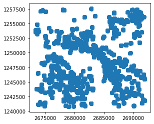

```python
montecarlo_df.plot()
```

# 3. Waldanteil berechnen

```python
wald = gpd.read_file("wald.shp")
```

```python
wald.crs = {"init": "epsg:2056"}
```

```python
montecarlo_df.crs = {"init": "epsg:2056"}
```

"init" setzt das Koordinatensystem der beiden Geodataframes

**Übung 7: Wald oder nicht Wald?**

```python
gpd.sjoin(montecarlo_df,wald)
```

|  | geometry | ID | Run_Nr | index_right | Wald | Shape_Leng | Shape_Area |
| --- | --- | --- | --- | --- | --- | --- | --- |
| 0 | POINT (2679025.000 1240868.000) | 28578.0 | 0 | 170 | 1 | 921225.341854 | 7.963237e+07 |
| 33 | POINT (2679011.000 1241691.000) | 3872.0 | 0 | 170 | 1 | 921225.341854 | 7.963237e+07 |
| 40 | POINT (2678608.000 1242040.000) | 9074.0 | 0 | 170 | 1 | 921225.341854 | 7.963237e+07 |
| 43 | POINT (2678572.000 1242131.000) | 15372.0 | 0 | 170 | 1 | 921225.341854 | 7.963237e+07 |
| 44 | POINT (2678590.000 1242117.000) | 16103.0 | 0 | 170 | 1 | 921225.341854 | 7.963237e+07 |
| ... | ... | ... | ... | ... | ... | ... | ... |
| 239 | POINT (2684890.000 1245155.000) | 2869.0 | 32 | 386 | 1 | 921225.341854 | 7.963237e+07 |
| 732 | POINT (2675470.000 1250921.000) | 26983.0 | 35 | 404 | 1 | 921225.341854 | 7.963237e+07 |
| 1065 | POINT (2690177.000 1257213.000) | 25508.0 | 35 | 38 | 1 | 921225.341854 | 7.963237e+07 |
| 316 | POINT (2682727.000 1245790.000) | 18325.0 | 36 | 380 | 1 | 921225.341854 | 7.963237e+07 |
| 86 | POINT (2681454.000 1242723.000) | 24629.0 | 47 | 242 | 1 | 921225.341854 | 7.963237e+07 |

24170 rows × 7 columns

```python
gpd.sjoin(wald,montecarlo_df)
```

|  | Wald | Shape_Leng | Shape_Area | geometry | index_right | ID | Run_Nr |
| --- | --- | --- | --- | --- | --- | --- | --- |
| 0 | 1 | 921225.341854 | 7.963237e+07 | POLYGON Z ((2689962.355 1245335.250 644.591, 2... | 236 | 5635.0 | 12 |
| 0 | 1 | 921225.341854 | 7.963237e+07 | POLYGON Z ((2689962.355 1245335.250 644.591, 2... | 236 | 5635.0 | 18 |
| 0 | 1 | 921225.341854 | 7.963237e+07 | POLYGON Z ((2689962.355 1245335.250 644.591, 2... | 236 | 5635.0 | 49 |
| 0 | 1 | 921225.341854 | 7.963237e+07 | POLYGON Z ((2689962.355 1245335.250 644.591, 2... | 236 | 5635.0 | 45 |
| 0 | 1 | 921225.341854 | 7.963237e+07 | POLYGON Z ((2689962.355 1245335.250 644.591, 2... | 236 | 5635.0 | 3 |
| ... | ... | ... | ... | ... | ... | ... | ... |
| 672 | 1 | 921225.341854 | 7.963237e+07 | POLYGON Z ((2688001.970 1251365.174 431.056, 2... | 753 | 18636.0 | 35 |
| 672 | 1 | 921225.341854 | 7.963237e+07 | POLYGON Z ((2688001.970 1251365.174 431.056, 2... | 753 | 18636.0 | 49 |
| 672 | 1 | 921225.341854 | 7.963237e+07 | POLYGON Z ((2688001.970 1251365.174 431.056, 2... | 753 | 18636.0 | 17 |
| 683 | 1 | 921225.341854 | 7.963237e+07 | POLYGON Z ((2691127.485 1246813.069 465.351, 2... | 433 | 3720.0 | 2 |
| 683 | 1 | 921225.341854 | 7.963237e+07 | POLYGON Z ((2691127.485 1246813.069 465.351, 2... | 433 | 3720.0 | 14 |

24170 rows × 7 columns

Beachte "Geometry" in dieser Reihenfolge, es entstehen Polygone -> Variante verwerfen

```python
monte_carlo_sjoin = gpd.sjoin(montecarlo_df,wald)
```

**Übung 8: Anteil Punkte im Wald**

```python
len(montecarlo_df)
```

```
53800
```

```python
len(monte_carlo_sjoin)
```

```
24170
```

```python
(24170/53800)*100
```

```
44.92565055762082
```

Prozent Zeckenstiche im Wald

```python
len(zeckenstiche)
```

```
1076
```

```python
mittelwerte = monte_carlo_sjoin.groupby("Run_Nr").size()/1075
```

```python
mittelwerte
```

```
Run_Nr
0     0.453953
1     0.454884
2     0.444651
3     0.451163
4     0.458605
5     0.440000
6     0.472558
7     0.449302
8     0.426047
9     0.441860
10    0.453023
11    0.434419
12    0.447442
13    0.460465
```

[output cut: 37 more lines]

**Übung 9: Mittelwerte visualisieren**

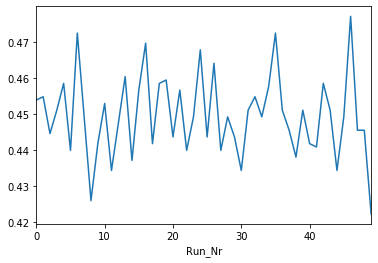

```python
mittelwerte.plot()
```

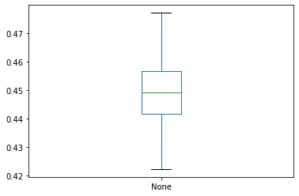

```python
mittelwerte.plot.box()
```

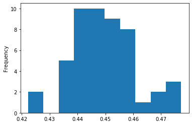

```python
mittelwerte.plot.hist()
```

Die Verteilung der Mittelwerte um einen Punkt lässt sich verschieden plotten